# TAEG

In this notebook, I analyze if the technology affinity as measured by the TA-EG differs between groups and if the TA-EG scores are related to other variables, including NASA-TLX, performance and TA-EG.

## Include necessary packages

```r
library(WRS2)
library(rcompanion)
library(feather)
library(ggplot2)
library(ez)
library(schoRsch)
library(MASS)
library(car)
library(tidyverse)
library(ggpubr)
library(rstatix)
```

## Load data

We are loading the experimental data in wide format.

```r
df_wide <- read_feather(path = here('../../data_frames/results_test_18-03-2020.file'))
```

[output not shown]

## Prepare the data

### Assign participants to the experimental group

- version 1 and 2 –> control group
- version 3 und 4 –> experimental group context free
- version 5 und 6–> experimental group context sensitive

```r
df_wide$group <- ifelse((df_wide$version == 5 | df_wide$version == 6), 'context-sensitive experimental group', ifelse((df_wide$version == 1 | df_wide$version == 2), 'controlgroup', 'context-free experimental group'))
```

```r
# Convert trial, group and subject number to factors in each dataframe
df_wide$group <- factor(df_wide$group)
df_wide$partnr <- factor(df_wide$partnr)
```

## Data Analysis

### Are there differences between the groups?

There are no signficant differences neither for the overall TAEG value nor for the subscales.

```r
df_wide %>% group_by(group) %>% summarise(taeg_groups = mean(TAEG),
            taeg_sd = (sd(TAEG)/sqrt(length(TAEG))))
```

| group | taeg_groups | taeg_sd |
| --- | --- | --- |
| context-free experimental group | 2.886640 | 0.1353503 |
| context-sensitive experimental group | 2.726817 | 0.1103184 |
| controlgroup | 2.646617 | 0.1179757 |

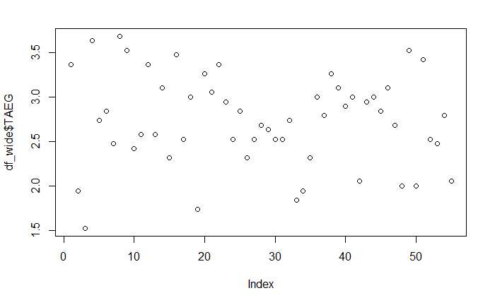

```r
plot(df_wide$TAEG)
```

```
`fun.y` is deprecated. Use `fun` instead.
```

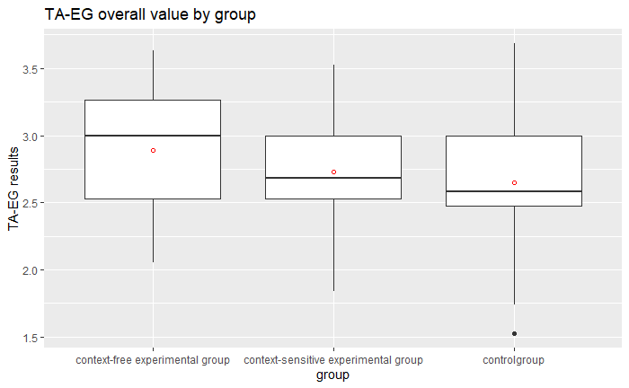

```r
## plot TA-EG mean
ggplot(df_wide,aes(x = group, y=TAEG) ) +
  geom_boxplot() +
  stat_summary(fun.y=mean,shape=1,col='red',geom='point') +
  labs(x="group",
       y = "TA-EG results",
       title="TA-EG overall value by group")
```

```r
## no significant group differences
kruskal.test(TAEG ~ group, data = df_wide)
```

```
    Kruskal-Wallis rank sum test

data:  TAEG by group
Kruskal-Wallis chi-squared = 1.668, df = 2, p-value = 0.4343
```

#### TA-EG subscale enthusiasm

```
`fun.y` is deprecated. Use `fun` instead.
```

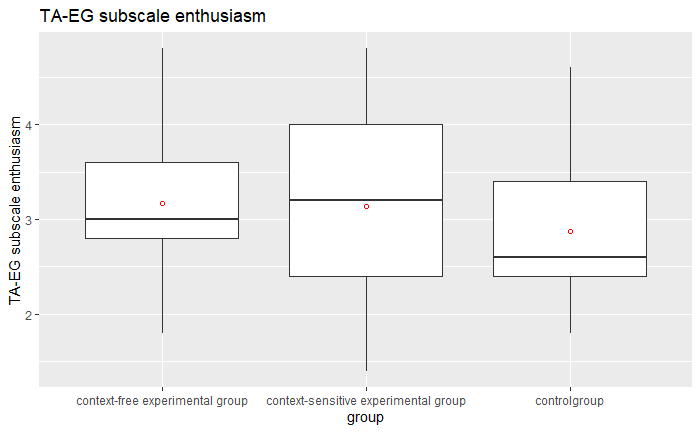

```r
ggplot(df_wide,aes(x = group, y=taeg_enthusiasm) ) +
  geom_boxplot() +
  stat_summary(fun.y=mean,shape=1,col='red',geom='point') +
  labs(x="group",
       y = "TA-EG subscale enthusiasm",
       title="TA-EG subscale enthusiasm")
```

```r
kruskal.test(taeg_enthusiasm ~ group, data = df_wide)
```

```
    Kruskal-Wallis rank sum test

data:  taeg_enthusiasm by group
Kruskal-Wallis chi-squared = 1.6028, df = 2, p-value = 0.4487
```

#### TA-EG subscale competence

```
`fun.y` is deprecated. Use `fun` instead.
```

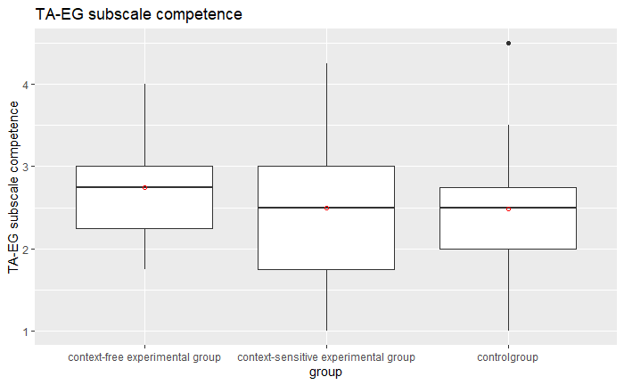

```r
ggplot(df_wide,aes(x = group, y=taeg_competence) ) +
  geom_boxplot() +
  stat_summary(fun.y=mean,shape=1,col='red',geom='point') +
  labs(x="group",
       y = "TA-EG subscale competence",
       title="TA-EG subscale competence")
```

```r
kruskal.test(taeg_competence ~ group, data = df_wide)
```

```
    Kruskal-Wallis rank sum test

data:  taeg_competence by group
Kruskal-Wallis chi-squared = 1.0858, df = 2, p-value = 0.5811
```

#### TA-EG subscale positive attitude

```
`fun.y` is deprecated. Use `fun` instead.
```

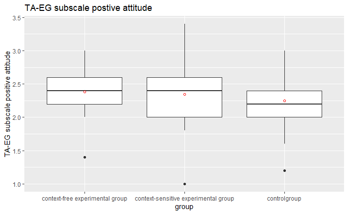

```r
ggplot(df_wide,aes(x = group, y=taeg_pos_attitude) ) +
  geom_boxplot() +
  stat_summary(fun.y=mean,shape=1,col='red',geom='point') +
  labs(x="group",
       y = "TA-EG subscale positive attitude",
       title="TA-EG subscale postive attitude")
```

```r
kruskal.test(taeg_pos_attitude ~ group, data = df_wide)
```

```
    Kruskal-Wallis rank sum test

data:  taeg_pos_attitude by group
Kruskal-Wallis chi-squared = 1.3604, df = 2, p-value = 0.5065
```

#### TA-EG subscale negative attitude

```
`fun.y` is deprecated. Use `fun` instead.
```

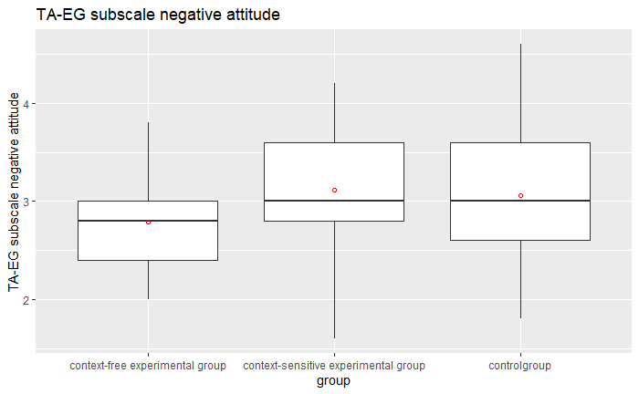

```r
ggplot(df_wide,aes(x = group, y=taeg_neg_attitude) ) +
  geom_boxplot() +
  stat_summary(fun.y=mean,shape=1,col='red',geom='point') +
  labs(x="group",
       y = "TA-EG subscale negative attitude",
       title="TA-EG subscale negative attitude")
```

```r
kruskal.test(taeg_neg_attitude ~ group, data = df_wide)
```

```
    Kruskal-Wallis rank sum test

data:  taeg_neg_attitude by group
Kruskal-Wallis chi-squared = 2.2881, df = 2, p-value = 0.3185
```

### Is there a relation between TA-EG scores and performance?

#### Correlation with nr of mistakes / entries after first interruption

```r
#calculate the measures
df_wide <- transform(df_wide, perf = mistakes_after_interruption / entries_after_interruption)
```

There is no significant correlation between TAEG mean and performance.

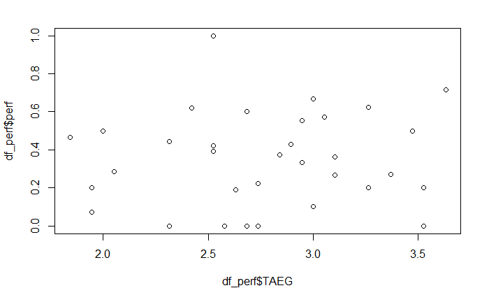

```r
plot(df_perf$perf~df_perf$TAEG)
```

```r
cor.test(df_perf$perf, df_perf$TAEG, method = 'pearson')
```

```
    Pearson's product-moment correlation

data:  df_perf$perf and df_perf$TAEG
t = 0.40434, df = 31, p-value = 0.6887
alternative hypothesis: true correlation is not equal to 0
95 percent confidence interval:
 -0.2777853  0.4056531
sample estimates:
       cor
0.07243114
```

##### TA-EG subscale enthusiasm (n.s.)

```r
plot(df_perf$perf~df_perf$taeg_enthusiasm)
```

[output not shown]

##### TA-EG subscale competence (n.s.)

`r`r plot(df_perf$perf~df_perf$taeg_competence)

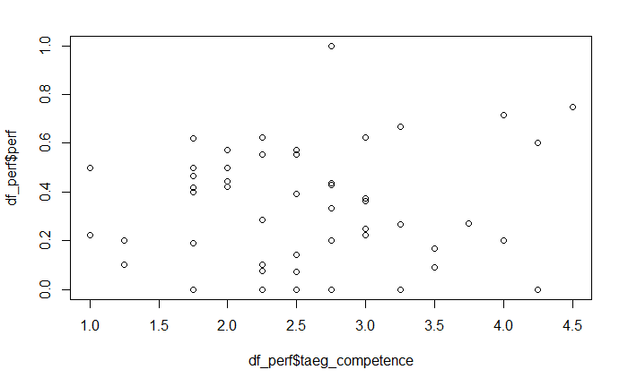

`r`r cor.test(df_perf$perf, df_perf$taeg_enthusiasm, method = ‘pearson’)

```
    Pearson's product-moment correlation

data:  df_perf$perf and df_perf$taeg_enthusiasm
t = -0.58873, df = 51, p-value = 0.5586
alternative hypothesis: true correlation is not equal to 0
95 percent confidence interval:
 -0.3447970  0.1924064
sample estimates:
        cor
-0.08216029
```

##### TA-EG subscale positive attitude (n.s.)

`r`r plot(df_perf$perf~df_perf$taeg_pos_attitude)

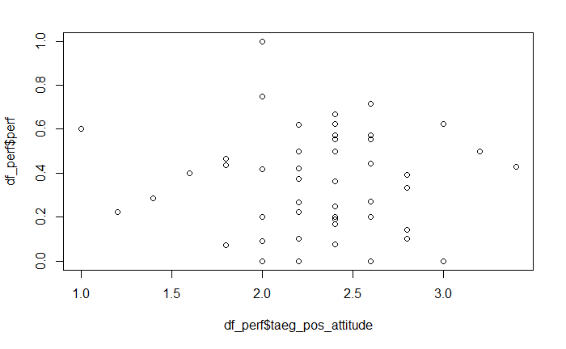

`r`r cor.test(df_perf$perf, df_perf$taeg_pos_attitude, method = ‘pearson’)

```
    Pearson's product-moment correlation

data:  df_perf$perf and df_perf$taeg_pos_attitude
t = -0.29126, df = 51, p-value = 0.772
alternative hypothesis: true correlation is not equal to 0
95 percent confidence interval:
 -0.3076562  0.2320992
sample estimates:
        cor
-0.04075117
```

`r`r plot(df_perf$perf~df_perf$taeg_neg_attitude)

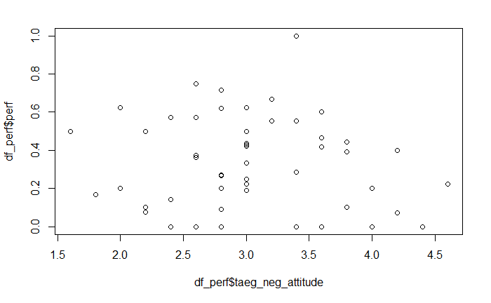

`r`r cor.test(df_perf$perf, df_perf$taeg_neg_attitude, method = ‘pearson’)

```
    Pearson's product-moment correlation

data:  df_perf$perf and df_perf$taeg_neg_attitude
t = -0.49629, df = 51, p-value = 0.6218
alternative hypothesis: true correlation is not equal to 0
95 percent confidence interval:
 -0.3333740  0.2048044
sample estimates:
       cor
-0.0693272
```

## influence on NASA-TLX values

There is a significant correlation between participants’ mean NASA-TLX score and their TA-EG score

`r`r library(matrixStats)

#### overall NASA-TLX score

`r`r nasa <- cbind(df_wide$NASATLX_1, df_wide$NASATLX_2, df_wide$NASATLX_3, df_wide$NASATLX_4) df_wide$NASATLX_mean <- rowMeans2(nasa) cor.test(df_wide$TAEG, df_wide$NASATLX_mean, method = ‘pearson’)

```
    Pearson's product-moment correlation

data:  df_wide$TAEG and df_wide$NASATLX_mean
t = 2.3497, df = 53, p-value = 0.02255
alternative hypothesis: true correlation is not equal to 0
95 percent confidence interval:
 0.04556615 0.52931562
sample estimates:
      cor
0.3071503
```

##### subscale enthusiasm (n.s.)

`r`r cor.test(df_wide$taeg_enthusiasm, df_wide$NASATLX_mean, method = ‘pearson’)

```
    Pearson's product-moment correlation

data:  df_wide$taeg_enthusiasm and df_wide$NASATLX_mean
t = 1.4698, df = 53, p-value = 0.1475
alternative hypothesis: true correlation is not equal to 0
95 percent confidence interval:
 -0.07113754  0.44008668
sample estimates:
      cor
0.1978944
```

subscale competence (p = .038)

`r`r cor.test(df_wide$taeg_competence, df_wide$NASATLX_mean, method = ‘pearson’)

```
    Pearson's product-moment correlation

data:  df_wide$taeg_competence and df_wide$NASATLX_mean
t = 2.1287, df = 53, p-value = 0.03794
alternative hypothesis: true correlation is not equal to 0
95 percent confidence interval:
 0.01658682 0.50811434
sample estimates:
     cor
0.280649
```

##### subscale positive attitude (n.s.)

`r`r cor.test(df_wide$taeg_pos_attitude, df_wide$NASATLX_mean, method = ‘pearson’)

```
    Pearson's product-moment correlation

data:  df_wide$taeg_pos_attitude and df_wide$NASATLX_mean
t = 0.98671, df = 53, p-value = 0.3283
alternative hypothesis: true correlation is not equal to 0
95 percent confidence interval:
 -0.1358303  0.3858554
sample estimates:
      cor
0.1343067
```

#### subscale negative attitude (p = .046)

`r`r cor.test(df_wide$taeg_neg_attitude, df_wide$NASATLX_mean, method = ‘pearson’)

```
    Pearson's product-moment correlation

data:  df_wide$taeg_neg_attitude and df_wide$NASATLX_mean
t = -2.0387, df = 53, p-value = 0.04648
alternative hypothesis: true correlation is not equal to 0
95 percent confidence interval:
 -0.499244864 -0.004703564
sample estimates:
       cor
-0.2696642
```

```
integer(0)
```

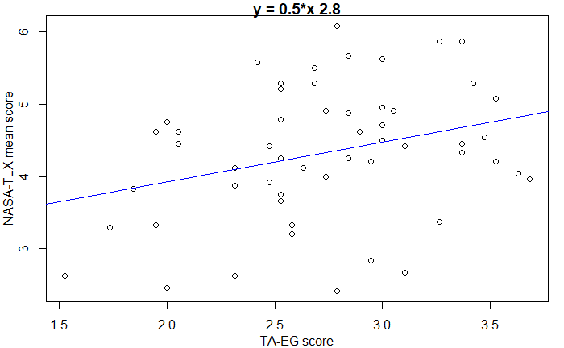

#### warm up task (n.s.)

`r`r plot(df_wide$TAEG~df_wide$NASATLX_1)

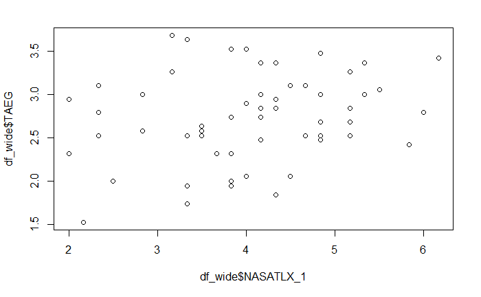

`r`r cor.test(df_wide$TAEG,df_wide$NASATLX_1, method = ‘pearson’)

```
    Pearson's product-moment correlation

data:  df_wide$TAEG and df_wide$NASATLX_1
t = 1.818, df = 53, p-value = 0.07471
alternative hypothesis: true correlation is not equal to 0
95 percent confidence interval:
 -0.02459133  0.47692777
sample estimates:
      cor
0.2422865
```

##### subscale taeg_enthusiasm (n.s.)

`r`r plot(df_wide$NASATLX_1 ~df_wide$taeg_enthusiasm)

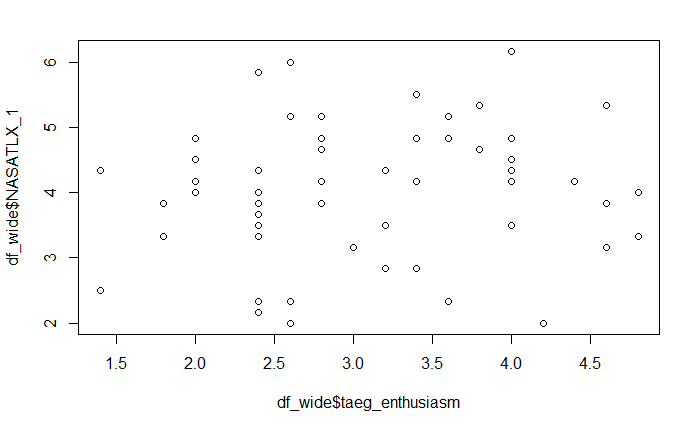

`r`r cor.test(df_wide$taeg_enthusiasm,df_wide$NASATLX_1, method = ‘pearson’)

```
    Pearson's product-moment correlation

data:  df_wide$taeg_enthusiasm and df_wide$NASATLX_1
t = 0.89584, df = 53, p-value = 0.3744
alternative hypothesis: true correlation is not equal to 0
95 percent confidence interval:
 -0.1479593  0.3752699
sample estimates:
      cor
0.1221319
```

##### subscale taeg_competence (n.s.)

`r`r plot(df_wide$NASATLX_1~df_wide$taeg_competence)

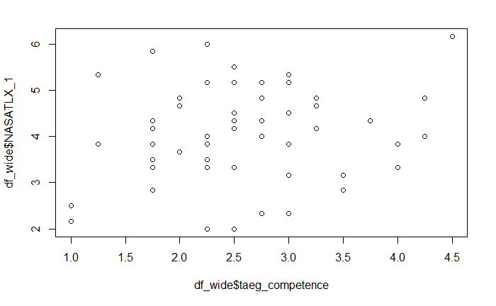

`r`r cor.test(df_wide$taeg_competence,df_wide$NASATLX_1, method = ‘pearson’)

```
    Pearson's product-moment correlation

data:  df_wide$taeg_competence and df_wide$NASATLX_1
t = 1.1016, df = 53, p-value = 0.2756
alternative hypothesis: true correlation is not equal to 0
95 percent confidence interval:
 -0.1204652  0.3990708
sample estimates:
      cor
0.1496135
```

##### subscale taeg_pos_attitude (n.s.)

`r`r plot(df_wide$NASATLX_1~df_wide$taeg_pos_attitude)

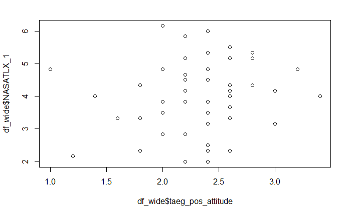

`r`r cor.test(df_wide$taeg_pos_attitude,df_wide$NASATLX_1, method = ‘pearson’)

```
    Pearson's product-moment correlation

data:  df_wide$taeg_pos_attitude and df_wide$NASATLX_1
t = 1.0437, df = 53, p-value = 0.3014
alternative hypothesis: true correlation is not equal to 0
95 percent confidence interval:
 -0.1282090  0.3924372
sample estimates:
      cor
0.1419152
```

##### subscale taeg_neg_attitude (p = .023)

```
integer(0)
```

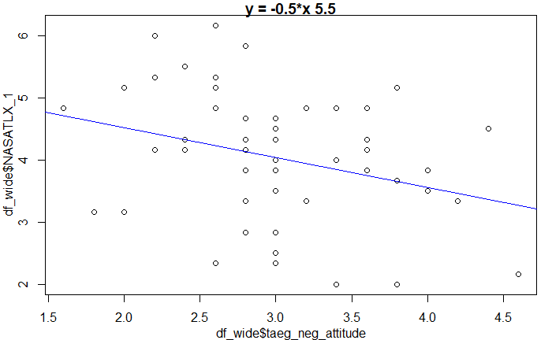

`r`r cor.test(df_wide$taeg_neg_attitude,df_wide$NASATLX_1, method = ‘pearson’)

```
    Pearson's product-moment correlation

data:  df_wide$taeg_neg_attitude and df_wide$NASATLX_1
t = -2.3428, df = 53, p-value = 0.02292
alternative hypothesis: true correlation is not equal to 0
95 percent confidence interval:
 -0.52867205 -0.04467432
sample estimates:
       cor
-0.3063408
```

#### first trial

no significant correlation

`r`r plot(df_wide$TAEG~df_wide$NASATLX_2)

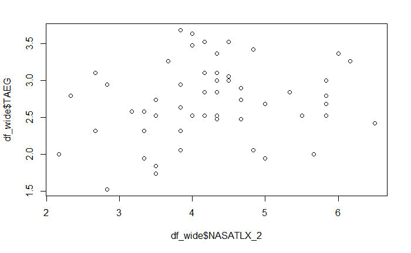

`r`r cor.test(df_wide$TAEG,df_wide$NASATLX_2, method = ‘pearson’)

```
    Pearson's product-moment correlation

data:  df_wide$TAEG and df_wide$NASATLX_2
t = 1.4281, df = 53, p-value = 0.1591
alternative hypothesis: true correlation is not equal to 0
95 percent confidence interval:
 -0.07672209  0.43554779
sample estimates:
      cor
0.1924931
```

##### subscale taeg_enthusiasm (n.s.)

`r`r plot(df_wide$NASATLX_2 ~df_wide$taeg_enthusiasm)

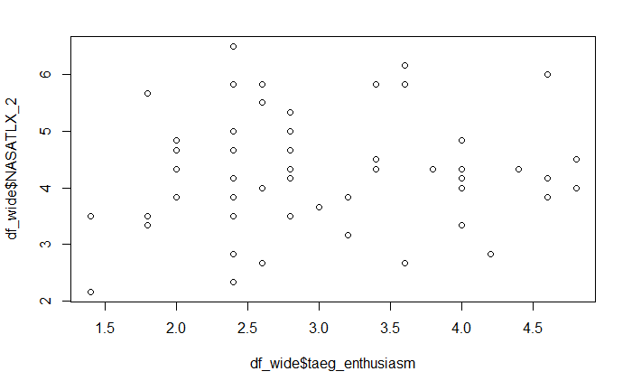

`r`r cor.test(df_wide$taeg_enthusiasm,df_wide$NASATLX_2, method = ‘pearson’)

```
    Pearson's product-moment correlation

data:  df_wide$taeg_enthusiasm and df_wide$NASATLX_2
t = 0.88595, df = 53, p-value = 0.3796
alternative hypothesis: true correlation is not equal to 0
95 percent confidence interval:
 -0.1492781  0.3741106
sample estimates:
      cor
0.1208033
```

##### subscale taeg_competence (n.s.)

`r`r plot(df_wide$NASATLX_2~df_wide$taeg_competence)

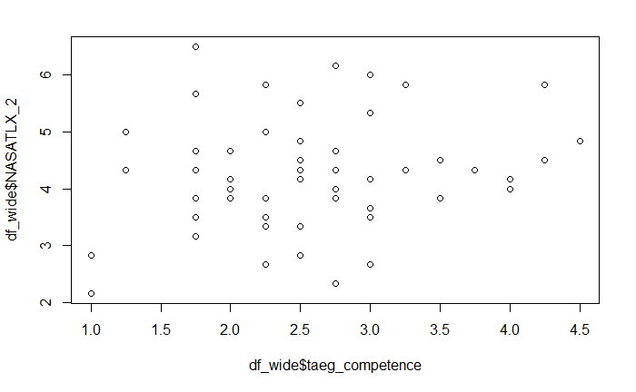

`r`r cor.test(df_wide$taeg_competence,df_wide$NASATLX_2, method = ‘pearson’)

```
    Pearson's product-moment correlation

data:  df_wide$taeg_competence and df_wide$NASATLX_2
t = 1.4757, df = 53, p-value = 0.1459
alternative hypothesis: true correlation is not equal to 0
95 percent confidence interval:
 -0.07033857  0.44073392
sample estimates:
      cor
0.1986658
```

##### subscale taeg_pos_attitude (n.s.)

`r`r plot(df_wide$NASATLX_2~df_wide$taeg_pos_attitude)

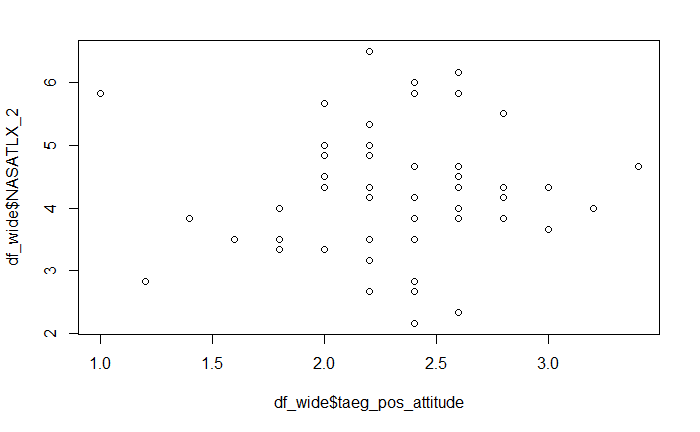

`r`r cor.test(df_wide$taeg_pos_attitude,df_wide$NASATLX_2, method = ‘pearson’)

```
    Pearson's product-moment correlation

data:  df_wide$taeg_pos_attitude and df_wide$NASATLX_2
t = 0.48156, df = 53, p-value = 0.6321
alternative hypothesis: true correlation is not equal to 0
95 percent confidence interval:
 -0.2028464  0.3255986
sample estimates:
       cor
0.06600273
```

##### subscale taeg_neg_attitude (n.s.)

`r`r plot(df_wide$NASATLX_2~df_wide$taeg_neg_attitude)

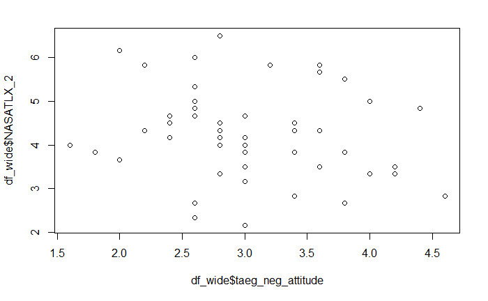

`r`r cor.test(df_wide$taeg_neg_attitude,df_wide$NASATLX_2, method = ‘pearson’)

```
    Pearson's product-moment correlation

data:  df_wide$taeg_neg_attitude and df_wide$NASATLX_2
t = -1.2059, df = 53, p-value = 0.2332
alternative hypothesis: true correlation is not equal to 0
95 percent confidence interval:
 -0.410896  0.106502
sample estimates:
       cor
-0.1634123
```

#### second trial (p = .013)

significant positive correlation

`r`r plot(df_wide$TAEG~df_wide$NASATLX_3) + abline(lm(df_wide$TAEG~df_wide$NASATLX_3), col = ‘blue’)

```
integer(0)
```

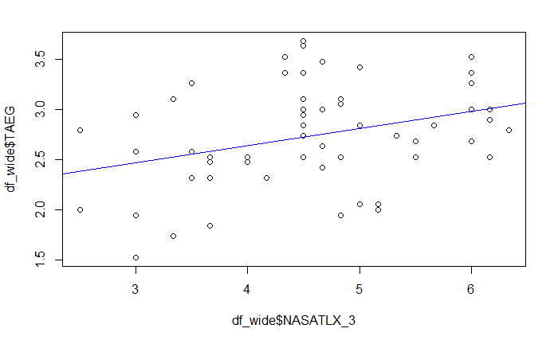

`r`r cor.test(df_wide$TAEG,df_wide$NASATLX_3, method = ‘pearson’)

```
    Pearson's product-moment correlation

data:  df_wide$TAEG and df_wide$NASATLX_3
t = 2.5737, df = 53, p-value = 0.01289
alternative hypothesis: true correlation is not equal to 0
95 percent confidence interval:
 0.07460917 0.54997416
sample estimates:
     cor
0.333309
```

##### subscale taeg_enthusiasm (n.s.)

`r`r plot(df_wide$NASATLX_3 ~df_wide$taeg_enthusiasm)

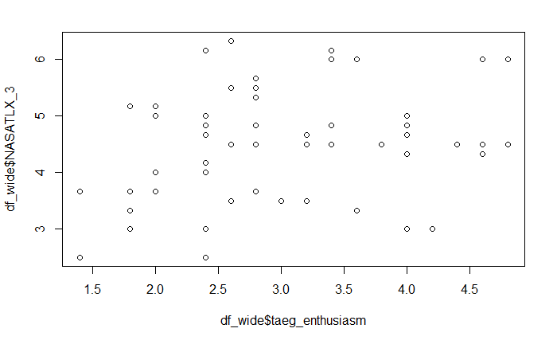

`r`r cor.test(df_wide$taeg_enthusiasm,df_wide$NASATLX_3, method = ‘pearson’)

```
    Pearson's product-moment correlation

data:  df_wide$taeg_enthusiasm and df_wide$NASATLX_3
t = 1.7319, df = 53, p-value = 0.08911
alternative hypothesis: true correlation is not equal to 0
95 percent confidence interval:
 -0.03607837  0.46799672
sample estimates:
     cor
0.231434
```

subscale taeg_competence (p <.01)

`r`r plot(df_wide$NASATLX_3~df_wide$taeg_competence)

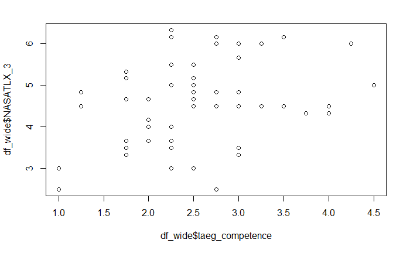

`r`r cor.test(df_wide$taeg_competence,df_wide$NASATLX_3, method = ‘pearson’)

```
    Pearson's product-moment correlation

data:  df_wide$taeg_competence and df_wide$NASATLX_3
t = 2.8374, df = 53, p-value = 0.00643
alternative hypothesis: true correlation is not equal to 0
95 percent confidence interval:
 0.1082780 0.5732165
sample estimates:
      cor
0.3631435
```

##### subscale taeg_pos_attitude (n.s.)

`r`r plot(df_wide$NASATLX_3~df_wide$taeg_pos_attitude)

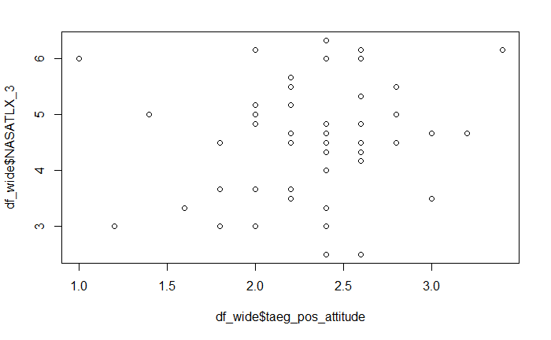

`r`r cor.test(df_wide$taeg_pos_attitude,df_wide$NASATLX_3, method = ‘pearson’)

```
    Pearson's product-moment correlation

data:  df_wide$taeg_pos_attitude and df_wide$NASATLX_3
t = 1.216, df = 53, p-value = 0.2294
alternative hypothesis: true correlation is not equal to 0
95 percent confidence interval:
 -0.1051411  0.4120393
sample estimates:
      cor
0.1647516
```

##### subscale taeg_neg_attitude (n.s.)

`r`r plot(df_wide$NASATLX_3~df_wide$taeg_neg_attitude)

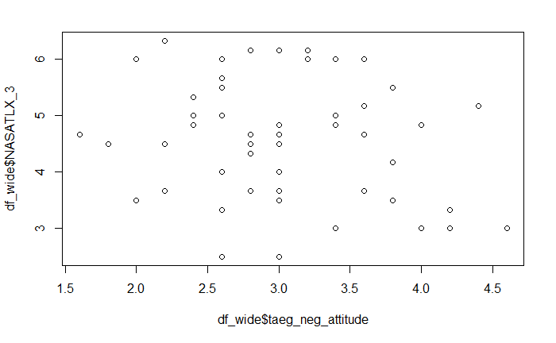

`r`r cor.test(df_wide$taeg_neg_attitude,df_wide$NASATLX_3, method = ‘pearson’)

```
    Pearson's product-moment correlation

data:  df_wide$taeg_neg_attitude and df_wide$NASATLX_3
t = -1.4775, df = 53, p-value = 0.1455
alternative hypothesis: true correlation is not equal to 0
95 percent confidence interval:
 -0.44092258  0.07010556
sample estimates:
       cor
-0.1988907
```

```
integer(0)
```

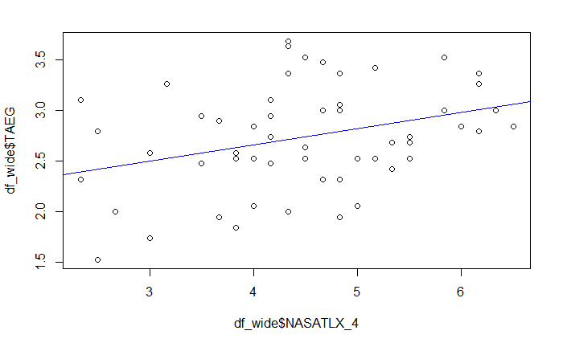

`r`r cor.test(df_wide$TAEG,df_wide$NASATLX_4, method = ‘pearson’)

```
    Pearson's product-moment correlation

data:  df_wide$TAEG and df_wide$NASATLX_4
t = 2.5551, df = 53, p-value = 0.01352
alternative hypothesis: true correlation is not equal to 0
95 percent confidence interval:
 0.07220704 0.54828730
sample estimates:
      cor
0.3311604
```

##### subscale enthusiasm (n.s.)

`r`r plot(df_wide$NASATLX_4 ~df_wide$taeg_enthusiasm)

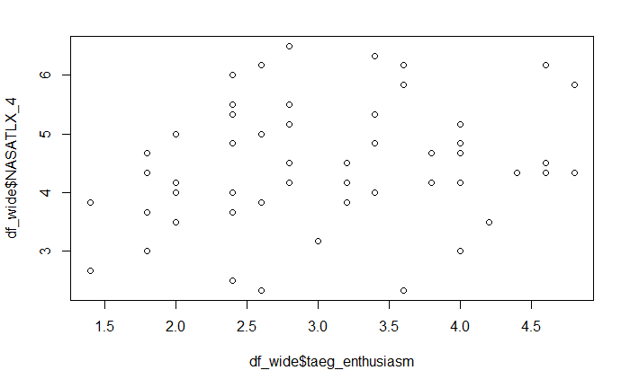

`r`r cor.test(df_wide$taeg_enthusiasm,df_wide$NASATLX_4, method = ‘pearson’)

```
    Pearson's product-moment correlation

data:  df_wide$taeg_enthusiasm and df_wide$NASATLX_4
t = 1.7481, df = 53, p-value = 0.08623
alternative hypothesis: true correlation is not equal to 0
95 percent confidence interval:
 -0.03390829  0.46969186
sample estimates:
      cor
0.2334893
```

##### subscale competence (p = .029)

`r`r plot(df_wide$NASATLX_4~df_wide$taeg_competence)

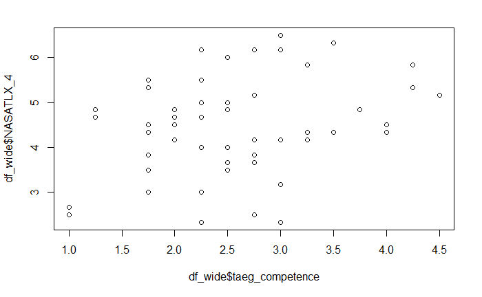

`r`r cor.test(df_wide$taeg_competence,df_wide$NASATLX_4, method = ‘pearson’)

```
    Pearson's product-moment correlation

data:  df_wide$taeg_competence and df_wide$NASATLX_4
t = 2.2493, df = 53, p-value = 0.02867
alternative hypothesis: true correlation is not equal to 0
95 percent confidence interval:
 0.03243632 0.51978412
sample estimates:
      cor
0.2951933
```

##### subscale positive attitude (n.s.)

`r`r plot(df_wide$NASATLX_4~df_wide$taeg_pos_attitude)

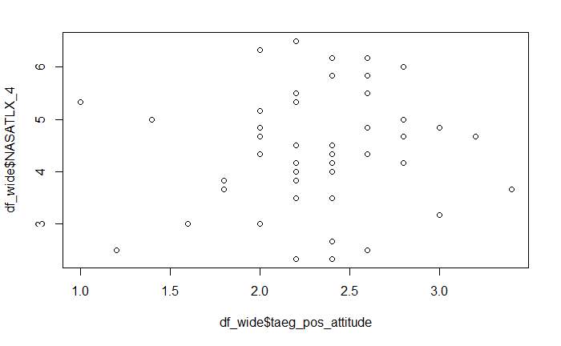

`r`r cor.test(df_wide$taeg_pos_attitude,df_wide$NASATLX_4, method = ‘pearson’)

```
    Pearson's product-moment correlation

data:  df_wide$taeg_pos_attitude and df_wide$NASATLX_4
t = 0.79695, df = 53, p-value = 0.429
alternative hypothesis: true correlation is not equal to 0
95 percent confidence interval:
 -0.1611299  0.3636188
sample estimates:
     cor
0.108819
```

##### subscale negative attitude (p = .029)

`r`r plot(df_wide$NASATLX_4~df_wide$taeg_neg_attitude)

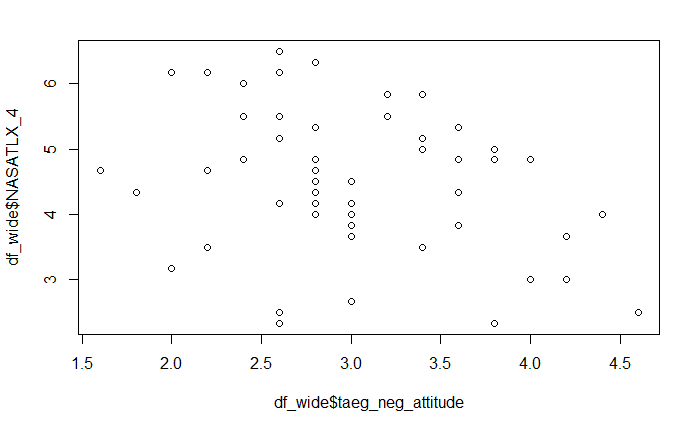

`r`r cor.test(df_wide$taeg_neg_attitude,df_wide$NASATLX_4, method = ‘pearson’)

```
    Pearson's product-moment correlation

data:  df_wide$taeg_neg_attitude and df_wide$NASATLX_4
t = -2.2414, df = 53, p-value = 0.02921
alternative hypothesis: true correlation is not equal to 0
95 percent confidence interval:
 -0.51902710 -0.03140068
sample estimates:
       cor
-0.2942466
```

### Influence on resumption speed

`r`r df_wide$res_speed_1 <- 1/df_wide$resumption_lag_1 df_wide$res_speed_2 <- 1/df_wide$resumption_lag_2 df_wide$res_speed_3 <- 1/df_wide$resumption_lag_3

`r`r resumption <- cbind(df_wide$res_speed_1, df_wide$res_speed_2, df_wide$res_speed_3) df_wide$res_speed_mean <- rowMeans2(resumption)

`r`r cor.test(df_wide$TAEG, df_wide$res_speed_mean, method = ‘pearson’)

```
    Pearson's product-moment correlation

data:  df_wide$TAEG and df_wide$res_speed_mean
t = -0.59084, df = 53, p-value = 0.5571
alternative hypothesis: true correlation is not equal to 0
95 percent confidence interval:
 -0.3389157  0.1884496
sample estimates:
        cor
-0.08089179
```

##### first trial

`r`r plot(df_wide$TAEG~df_wide$res_speed_1)

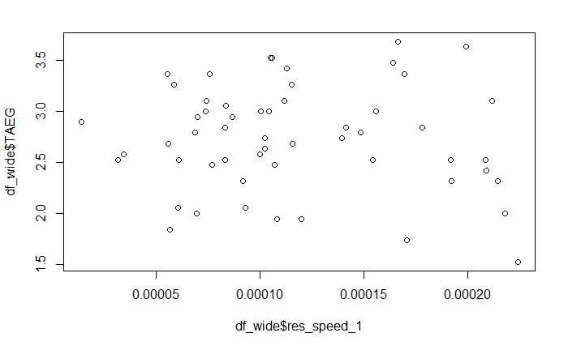

`r`r cor.test(df_wide$TAEG,df_wide$res_speed_1, method = ‘pearson’)

```
    Pearson's product-moment correlation

data:  df_wide$TAEG and df_wide$res_speed_1
t = -0.63959, df = 53, p-value = 0.5252
alternative hypothesis: true correlation is not equal to 0
95 percent confidence interval:
 -0.3448087  0.1820057
sample estimates:
        cor
-0.08751734
```

#### second trial (n.s.)

`r`r plot(df_wide$TAEG~df_wide$res_speed_2)

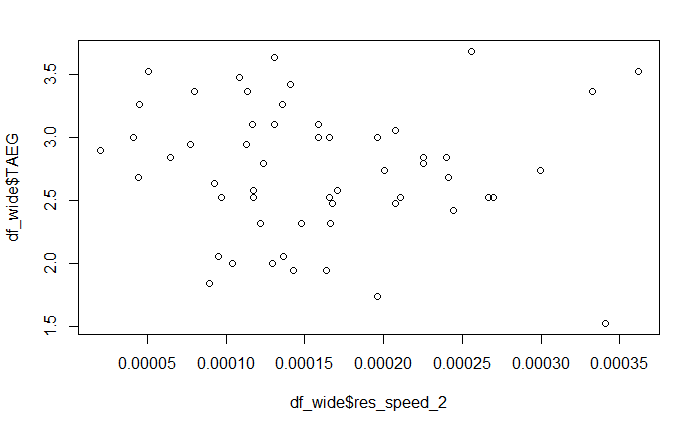

`r`r cor.test(df_wide$TAEG,df_wide$res_speed_2, method = ‘pearson’)

```
    Pearson's product-moment correlation

data:  df_wide$TAEG and df_wide$res_speed_2
t = -0.44622, df = 53, p-value = 0.6573
alternative hypothesis: true correlation is not equal to 0
95 percent confidence interval:
 -0.3212610  0.2074867
sample estimates:
        cor
-0.06117801
```

#### third trial (n.s.)

`r`r plot(df_wide$TAEG~df_wide$res_speed_3)

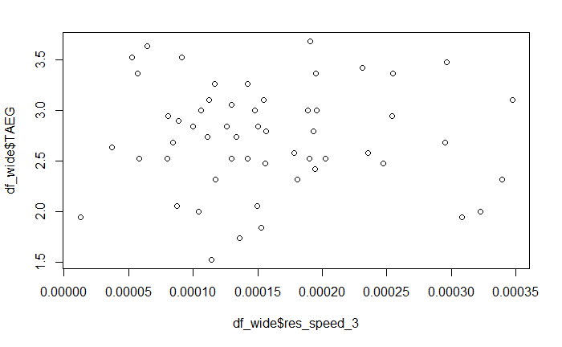

`r`r cor.test(df_wide$TAEG,df_wide$res_speed_3, method = ‘pearson’)

```
    Pearson's product-moment correlation

data:  df_wide$TAEG and df_wide$res_speed_3
t = -0.1556, df = 53, p-value = 0.8769
alternative hypothesis: true correlation is not equal to 0
95 percent confidence interval:
 -0.2850497  0.2453194
sample estimates:
        cor
-0.02136845
```

### influence on list input lag after the first trial (n.s.)

`r`r cor.test(df_wide$TAEG,df_wide$list_input_lag_1)

```
    Pearson's product-moment correlation

data:  df_wide$TAEG and df_wide$list_input_lag_1
t = 1.323, df = 50, p-value = 0.1919
alternative hypothesis: true correlation is not equal to 0
95 percent confidence interval:
 -0.09369402  0.43497800
sample estimates:
      cor
0.1839087
```

### influence on list input lag after the second trial (n.s.)

`r`r cor.test(df_wide$TAEG,df_wide$list_input_lag_2)

```
    Pearson's product-moment correlation

data:  df_wide$TAEG and df_wide$list_input_lag_2
t = 1.4838, df = 48, p-value = 0.1444
alternative hypothesis: true correlation is not equal to 0
95 percent confidence interval:
 -0.07319818  0.46089802
sample estimates:
      cor
0.2094163
```

[figure not shown]

## influence on purposeful action lags (n.s.)

[output not shown]

`r`r # convert group and trial to factors df_exp$group <- factor(df_exp$group) df_exp$ppa_log_1 <- log(df_exp$purposeful_action_lag_1)

[output not shown]

`r`r cor.test(df_exp$TAEG,df_exp$ppa_log_1)

```
    Pearson's product-moment correlation

data:  df_exp$TAEG and df_exp$ppa_log_1
t = 0.67296, df = 32, p-value = 0.5058
alternative hypothesis: true correlation is not equal to 0
95 percent confidence interval:
 -0.2291899  0.4387692
sample estimates:
      cor
0.1181315
```

`r`r cor.test(df_exp$TAEG,df_exp$ppa_log_2)

```
    Pearson's product-moment correlation

data:  df_exp$TAEG and df_exp$ppa_log_2
t = -0.68926, df = 32, p-value = 0.4956
alternative hypothesis: true correlation is not equal to 0
95 percent confidence interval:
 -0.4410757  0.2264784
sample estimates:
       cor
-0.1209506
```

`r`r cor.test(df_exp$TAEG,df_exp$ppa_log_3)

```
    Pearson's product-moment correlation

data:  df_exp$TAEG and df_exp$ppa_log_3
t = 1.8361, df = 30, p-value = 0.07628
alternative hypothesis: true correlation is not equal to 0
95 percent confidence interval:
 -0.0347051  0.6000295
sample estimates:
      cor
0.3178351
```